# Advanced Analytics and Machine Learning for Car Insurance Claim Prediction

Shantanu Motiani

2023-11-05

```r
library( ggplot2 )       # For the ggplot function
library( plyr )          # For the 'mutate' function
library( forcats )       # For the "fct_collapse" function
library( Hmisc )         # For missing values
library( naniar)         # For visualizing missing values
library( rpart )         # For the "CART" algorithm
library( rpart.plot )    # To plot decision trees
library( C50 )           # For the "C5.0" algorithm
library( randomForest )  # For the "Random Forest" algorithm
library( liver )         # For the "adult" dataset & the "partition" function
library( pROC )          # For ROC plot using "plot.roc" function
library( ggplot2 )       # For ggroc plot
library( Boruta )        # For feature importance
library( psych )         # For correlation plot
library( dplyr )
```

# 1 Introduction

Car insurance is a type of financial protection designed to cover the costs associated with accidents, theft, and other unforeseen events involving a motor vehicle. It is a contract between an individual (the policyholder) and an insurance company. In exchange for regular premium payments, the insurance company agrees to provide financial assistance in case of covered events.

Insurance companies conduct risk assessments to determine the likelihood of a policyholder making a claim and the potential cost of that claim. This process is crucial for several reasons:

1. Setting Premiums: Risk assessment allows insurance companies to determine appropriate premium rates for policies. Policies for individuals or entities with a higher likelihood of making claims or incurring costly losses are generally charged higher premiums. This ensures that the premiums collected are sufficient to cover potential payouts.
2. Maintaining Financial Stability: Accurately assessing risk helps insurance companies maintain their financial stability. If premiums are too low relative to the risk, the company may not have enough funds to cover claims, potentially leading to financial instability.
3. Avoiding Adverse Selection: Adverse selection occurs when individuals or businesses with a higher likelihood of making a claim are more inclined to purchase insurance. If insurers do not assess risk properly, they may attract a disproportionate number of high-risk policyholders, which can lead to financial losses.
4. Balancing Coverage and Costs: Insurance companies need to strike a balance between offering comprehensive coverage and maintaining affordability for policyholders. Risk assessment helps them determine the level of coverage they can provide while still remaining financially viable.

In summary, risk assessment is a cornerstone of the insurance industry’s profitability. It helps insurers strike a balance between offering coverage, managing costs, and mitigating financial risks, ultimately allowing them to generate profits while fulfilling their promise to policyholders.

# 2 Business Understanding

The goal of this project is to predict the probability that an individual seeking auto insurance will be in an accident and then to forecast the potential cost of an ensuing claim. Using data of existing customers, we can identify the likely characteristics of high risk drivers. Not only will this allow us to flag high risk clients, it will also allow us to construct a general profile of such drivers.

Following our analyses, insurance providers can accordingly allocate (or deny) a suitable insurance policy to such clients. They can also identify potentially fraudulent claims from clients that were highly unlikely to make claims. However, these problems are not within the scope of this project.

A binary classification model will be constructed to estimate the probability of claiming insurance (1 or 0), this can be done by training and comparing different models like logistic regression, decision trees, and k-nearest neighbors. This approach builds on methods for model training/testing which underlie modern machine learning strategies for classification and prediction.

# 3 Data Understanding

This dataset was obtained from https://www.kaggle.com/datasets/sagnik1511/car-insurance-data

```r
insurance = read.csv("Car_Insurance_Claim.csv")
head(insurance)
```

```
        ID   AGE GENDER     RACE DRIVING_EXPERIENCE   EDUCATION        INCOME
  1 569520   65+ female majority               0-9y high school   upper class
  2 750365 16-25   male majority               0-9y        none       poverty
  3 199901 16-25 female majority               0-9y high school working class
  4 478866 16-25   male majority               0-9y  university working class
  5 731664 26-39   male majority             10-19y        none working class
  6 877557 40-64 female majority             20-29y high school   upper class
    CREDIT_SCORE VEHICLE_OWNERSHIP VEHICLE_YEAR MARRIED CHILDREN POSTAL_CODE
  1    0.6290273                 1   after 2015       0        1       10238
  2    0.3577571                 0  before 2015       0        0       10238
  3    0.4931458                 1  before 2015       0        0       10238
  4    0.2060129                 1  before 2015       0        1       32765
  5    0.3883659                 1  before 2015       0        0       32765
  6    0.6191274                 1   after 2015       0        1       10238
    ANNUAL_MILEAGE VEHICLE_TYPE SPEEDING_VIOLATIONS DUIS PAST_ACCIDENTS OUTCOME
  1          12000        sedan                   0    0              0       0
  2          16000        sedan                   0    0              0       1
  3          11000        sedan                   0    0              0       0
  4          11000        sedan                   0    0              0       0
  5          12000        sedan                   2    0              1       1
  6          13000        sedan                   3    0              3       0
```

```r
nrow(insurance)
```

```
  [1] 10000
```

As we can see, the dataset has 10000 rows

```r
ncol(insurance)
```

```
  [1] 19
```

…and 19 columns.

Let’s look at an overview of the dataset

```r
str(insurance)
```

```
  'data.frame': 10000 obs. of  19 variables:
   $ ID                 : int  569520 750365 199901 478866 731664 877557 930134 461006 68366 445911 ...
   $ AGE                : chr  "65+" "16-25" "16-25" "16-25" ...
   $ GENDER             : chr  "female" "male" "female" "male" ...
   $ RACE               : chr  "majority" "majority" "majority" "majority" ...
   $ DRIVING_EXPERIENCE : chr  "0-9y" "0-9y" "0-9y" "0-9y" ...
   $ EDUCATION          : chr  "high school" "none" "high school" "university" ...
   $ INCOME             : chr  "upper class" "poverty" "working class" "working class" ...
   $ CREDIT_SCORE       : num  0.629 0.358 0.493 0.206 0.388 ...
   $ VEHICLE_OWNERSHIP  : num  1 0 1 1 1 1 0 0 0 1 ...
   $ VEHICLE_YEAR       : chr  "after 2015" "before 2015" "before 2015" "before 2015" ...
   $ MARRIED            : num  0 0 0 0 0 0 1 0 1 0 ...
   $ CHILDREN           : num  1 0 0 1 0 1 1 1 0 1 ...
   $ POSTAL_CODE        : int  10238 10238 10238 32765 32765 10238 10238 10238 10238 32765 ...
   $ ANNUAL_MILEAGE     : num  12000 16000 11000 11000 12000 13000 13000 14000 13000 11000 ...
   $ VEHICLE_TYPE       : chr  "sedan" "sedan" "sedan" "sedan" ...
   $ SPEEDING_VIOLATIONS: int  0 0 0 0 2 3 7 0 0 0 ...
   $ DUIS               : int  0 0 0 0 0 0 0 0 0 0 ...
   $ PAST_ACCIDENTS     : int  0 0 0 0 1 3 3 0 0 0 ...
   $ OUTCOME            : num  0 1 0 0 1 0 0 1 0 1 ...
```

| Variable | Type | Description |
| --- | --- | --- |
| ID | Categorical (nominal) | ID of the client |
| AGE | Categorical (ordinal) | Age range |
| GENDER | Categorical (binary) | Male or Female |
| RACE | Categorical (binary) | Majority or Minority |
| DRIVING_EXPERIENCE | Categorical (ordinal) | Duration ranges |
| EDUCATION | Categorical (ordinal) | Education Level |
| INCOME | Categorical (ordinal) | Income Levels |
| CREDIT_SCORE | Numerical (continuous) | Number between 0-1 |
| VEHICLE_OWNERSHIP | Categorical (binary) | 0 or 1, indicating ownership |
| VEHICLE_YEAR | Categorical (binary) | Before or after 2015 |
| MARRIED | Categorical (binary) | 0 or 1, indicating marital status |
| CHILDREN | Categorical (binary) | 0 or 1, indicating parental status |
| POSTAL_CODE | Numerical (continuous) | Number indicating postal code |
| ANNUAL_MILEAGE | Numerical (continuous) | Number indicating annual mileage |
| VEHICLE_TYPE | Categorical (binary) | Sedan or sports car |
| SPEEDING_VIOLATIONS | Numerical (discrete) | Indicating the number of speeding violations |
| DUIS | Numerical (discrete) | Indicating the number of DUIs |
| PAST_ACCIDENTS | Numerical (discrete) | Indicating the number of past accidents |
| OUTCOME | Numerical (binary). | 0 or 1, Indicating if a claim was filed or not |

Let’s look at a summary of the dataset:

```r
summary(insurance)
```

```
         ID             AGE               GENDER              RACE
   Min.   :   101   Length:10000       Length:10000       Length:10000
   1st Qu.:249639   Class :character   Class :character   Class :character
   Median :501777   Mode  :character   Mode  :character   Mode  :character
   Mean   :500522
   3rd Qu.:753975
   Max.   :999976

   DRIVING_EXPERIENCE  EDUCATION            INCOME           CREDIT_SCORE
   Length:10000       Length:10000       Length:10000       Min.   :0.0534
   Class :character   Class :character   Class :character   1st Qu.:0.4172
   Mode  :character   Mode  :character   Mode  :character   Median :0.5250
                                                            Mean   :0.5158
                                                            3rd Qu.:0.6183
                                                            Max.   :0.9608
                                                            NA's   :982
   VEHICLE_OWNERSHIP VEHICLE_YEAR          MARRIED          CHILDREN
   Min.   :0.000     Length:10000       Min.   :0.0000   Min.   :0.0000
   1st Qu.:0.000     Class :character   1st Qu.:0.0000   1st Qu.:0.0000
   Median :1.000     Mode  :character   Median :0.0000   Median :1.0000
   Mean   :0.697                        Mean   :0.4982   Mean   :0.6888
   3rd Qu.:1.000                        3rd Qu.:1.0000   3rd Qu.:1.0000
   Max.   :1.000                        Max.   :1.0000   Max.   :1.0000

    POSTAL_CODE    ANNUAL_MILEAGE  VEHICLE_TYPE       SPEEDING_VIOLATIONS
   Min.   :10238   Min.   : 2000   Length:10000       Min.   : 0.000
   1st Qu.:10238   1st Qu.:10000   Class :character   1st Qu.: 0.000
   Median :10238   Median :12000   Mode  :character   Median : 0.000
   Mean   :19865   Mean   :11697                      Mean   : 1.483
   3rd Qu.:32765   3rd Qu.:14000                      3rd Qu.: 2.000
   Max.   :92101   Max.   :22000                      Max.   :22.000
                   NA's   :957
        DUIS        PAST_ACCIDENTS      OUTCOME
   Min.   :0.0000   Min.   : 0.000   Min.   :0.0000
   1st Qu.:0.0000   1st Qu.: 0.000   1st Qu.:0.0000
   Median :0.0000   Median : 0.000   Median :0.0000
   Mean   :0.2392   Mean   : 1.056   Mean   :0.3133
   3rd Qu.:0.0000   3rd Qu.: 2.000   3rd Qu.:1.0000
   Max.   :6.0000   Max.   :15.000   Max.   :1.0000
```

It is observed that both the variables CREDIT_SCORE and ANNUAL_MILEAGE have missing values. In order to utilize this data, we will replace the missing values with the mean value of the respective variables.

```r
sum(is.na(insurance))
```

```
  [1] 1939
```

```r
insurance $ CREDIT_SCORE = impute( insurance $ CREDIT_SCORE, mean )
summary(insurance $ CREDIT_SCORE)
```

```
   982 values imputed to 0.5158128
```

```
     Min. 1st Qu.  Median    Mean 3rd Qu.    Max.
  0.05336 0.43151 0.51581 0.51581 0.60761 0.96082
```

```r
insurance $ ANNUAL_MILEAGE = impute( insurance $ ANNUAL_MILEAGE, mean )
summary(insurance $ ANNUAL_MILEAGE)
```

```
   957 values imputed to 11697
```

```
     Min. 1st Qu.  Median    Mean 3rd Qu.    Max.
     2000   10000   11697   11697   13000   22000
```

```r
sum(is.na(insurance))
```

```
  [1] 0
```

```r
summary(insurance)
```

```
   982 values imputed to 0.5158128


   957 values imputed to 11697
```

```
         ID             AGE               GENDER              RACE
   Min.   :   101   Length:10000       Length:10000       Length:10000
   1st Qu.:249639   Class :character   Class :character   Class :character
   Median :501777   Mode  :character   Mode  :character   Mode  :character
   Mean   :500522
   3rd Qu.:753975
   Max.   :999976
   DRIVING_EXPERIENCE  EDUCATION            INCOME           CREDIT_SCORE
   Length:10000       Length:10000       Length:10000       Min.   :0.05336
   Class :character   Class :character   Class :character   1st Qu.:0.43151
   Mode  :character   Mode  :character   Mode  :character   Median :0.51581
                                                            Mean   :0.51581
                                                            3rd Qu.:0.60761
                                                            Max.   :0.96082
   VEHICLE_OWNERSHIP VEHICLE_YEAR          MARRIED          CHILDREN
   Min.   :0.000     Length:10000       Min.   :0.0000   Min.   :0.0000
   1st Qu.:0.000     Class :character   1st Qu.:0.0000   1st Qu.:0.0000
   Median :1.000     Mode  :character   Median :0.0000   Median :1.0000
   Mean   :0.697                        Mean   :0.4982   Mean   :0.6888
   3rd Qu.:1.000                        3rd Qu.:1.0000   3rd Qu.:1.0000
   Max.   :1.000                        Max.   :1.0000   Max.   :1.0000
    POSTAL_CODE    ANNUAL_MILEAGE  VEHICLE_TYPE       SPEEDING_VIOLATIONS
   Min.   :10238   Min.   : 2000   Length:10000       Min.   : 0.000
   1st Qu.:10238   1st Qu.:10000   Class :character   1st Qu.: 0.000
   Median :10238   Median :11697   Mode  :character   Median : 0.000
   Mean   :19865   Mean   :11697                      Mean   : 1.483
   3rd Qu.:32765   3rd Qu.:13000                      3rd Qu.: 2.000
   Max.   :92101   Max.   :22000                      Max.   :22.000
        DUIS        PAST_ACCIDENTS      OUTCOME
   Min.   :0.0000   Min.   : 0.000   Min.   :0.0000
   1st Qu.:0.0000   1st Qu.: 0.000   1st Qu.:0.0000
   Median :0.0000   Median : 0.000   Median :0.0000
   Mean   :0.2392   Mean   : 1.056   Mean   :0.3133
   3rd Qu.:0.0000   3rd Qu.: 2.000   3rd Qu.:1.0000
   Max.   :6.0000   Max.   :15.000   Max.   :1.0000
```

Let’s summarize the target variable `OUTCOME`

```r
table(insurance$OUTCOME)
```

```
     0    1
  6867 3133
```

```r
round(3133/(3133+6867), 2)
```

```
  [1] 0.31
```

Therefore, 31% of customers in the dataset claimed insurance.

# 4 Exploratory Data Analysis

The goal of this section is to identify the characteristics of customers that claim insurance through plotting, charting and data representation.

## 4.1 Correlation plots of numerical variables

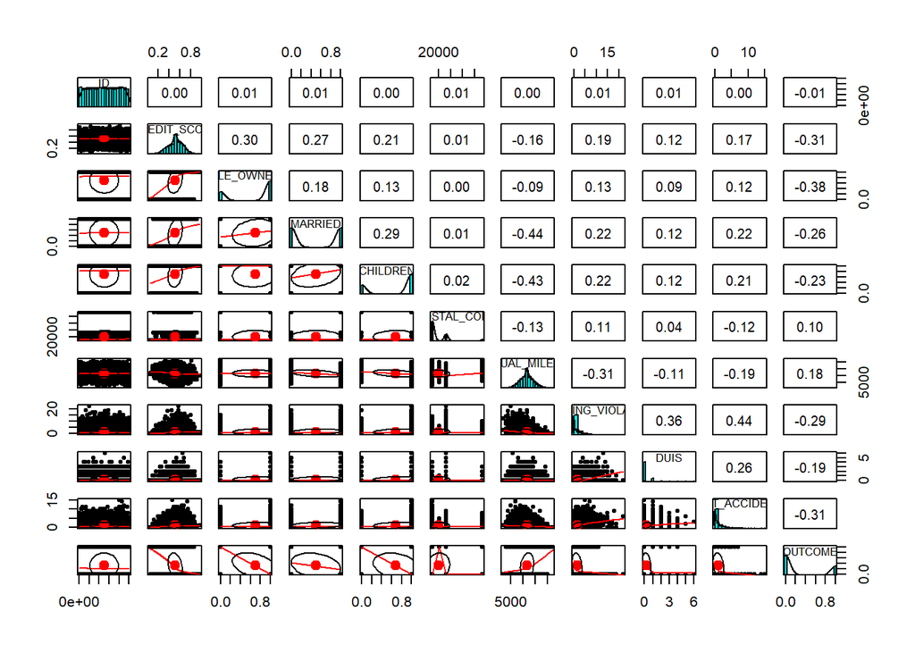

```r
nums = select_if(insurance, is.numeric)
pairs.panels( nums )
```

As we can see, we have no highly directly or inversely proportional numerical columns. Therefore, for now, we will consider all of them (except `ID)` for our EDA.

## 4.2 Investigating the target variable *OUTCOME*

Here we report a bar plot and summary for the target variable `OUTCOME` as follows:

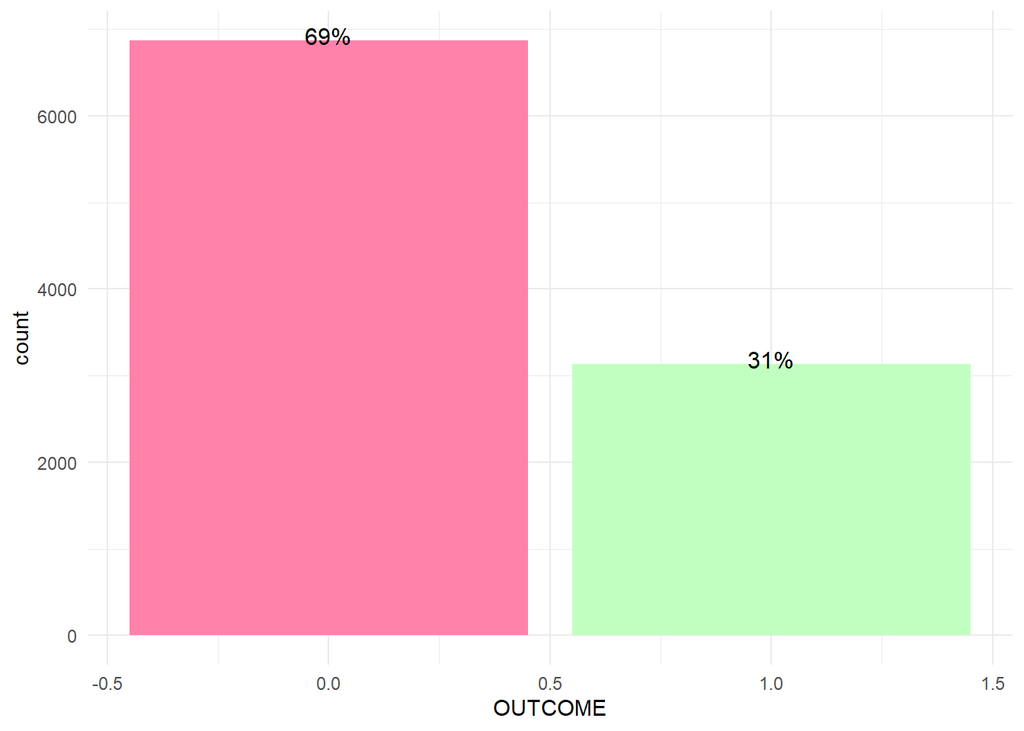

```r
ggplot( data = insurance, aes( x = OUTCOME, label = scales::percent( prop.table( stat( count ) ) ) ) ) +
    geom_bar( fill = c( "palevioletred1", "darkseagreen1" ) ) +
    geom_text( stat = 'count', vjust = 0.2, size = 4 ) +
    theme_minimal()
```

Therefore, 31% of customers in the dataset claimed insurance.

## 4.3 Investigating *Age*

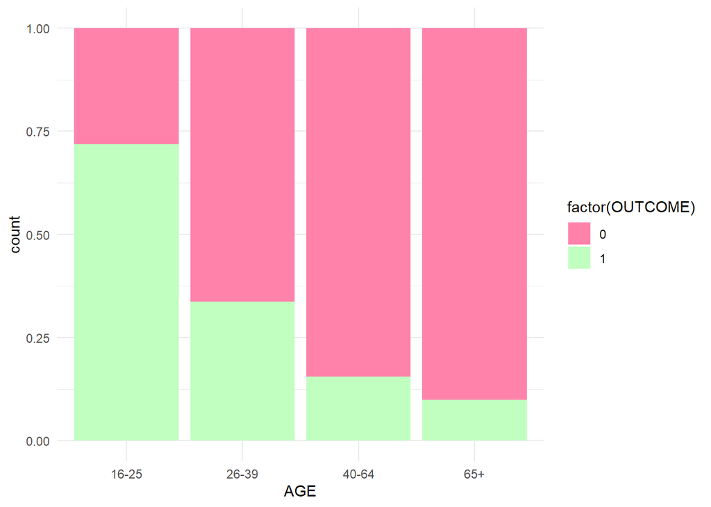

```r
ggplot(data = insurance) +
  geom_bar(aes(x = AGE, fill = factor(OUTCOME)), position = "fill") +
  scale_fill_manual(values = c("palevioletred1", "darkseagreen1")) +
  theme_minimal()
```

## 4.4 Investigating *Gender*

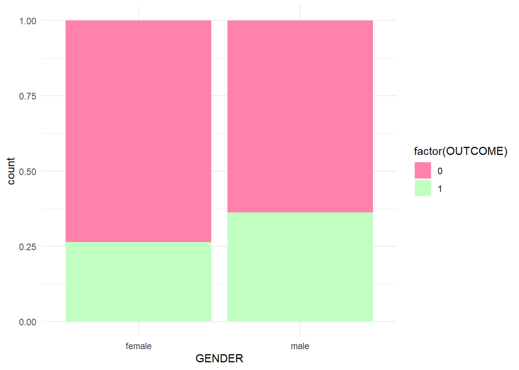

```r
ggplot(data = insurance) +
  geom_bar(aes(x = GENDER, fill = factor(OUTCOME)), position = "fill") +
  scale_fill_manual(values = c("palevioletred1", "darkseagreen1")) +
  theme_minimal()
```

The graphic presented above illustrates a somewhat higher frequency of insurance claims being filed by male drivers.

The above plot does not indicate a clear graphical evidence of the predictive importance of *Gender*. Thus, we apply the following hypothesis testing for dependency between variables *Gender* and *Outcome*

```r
chisq.test( table( insurance $ OUTCOME, insurance $ GENDER ) )
```

```
    Pearson's Chi-squared test with Yates' continuity correction

  data:  table(insurance$OUTCOME, insurance$GENDER)
  X-squared = 114.47, df = 1, p-value < 2.2e-16
```

Since the *p*-value < 2.2e-16 is less than the significance level of $\alpha=0.05$, the null hypothesis is rejected. This implies that the proportion of insurance claims differs between the two groups, and that the variable `Gender` is useful for predicting the proportion of insurance claims filed.

## 4.5 Investigating *Race*

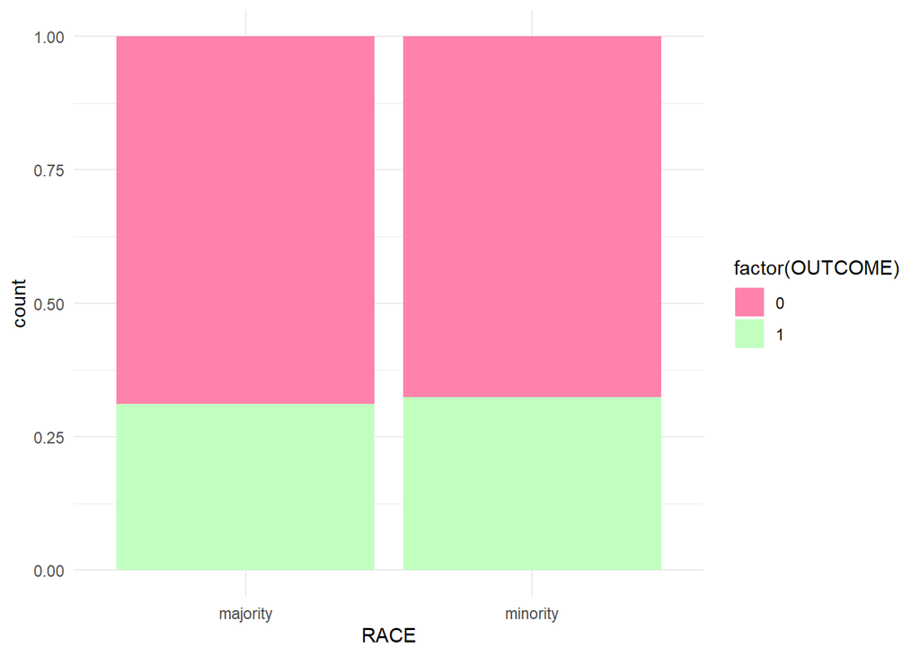

```r
ggplot(data = insurance) +
  geom_bar(aes(x = RACE, fill = factor(OUTCOME)), position = "fill") +
  scale_fill_manual(values = c("palevioletred1", "darkseagreen1")) +
  theme_minimal()
```

Based on the data depicted in the above bar graph, it is apparent that there is no statistically significant discrepancy in the occurrence of insurance claims among various racial groupings. Therefore, in order to determine the presence of a statistically significant difference, a Chi-squared Test is employed.

```r
chisq.test(table(insurance $ OUTCOME, insurance $ RACE))
```

```
    Pearson's Chi-squared test with Yates' continuity correction

  data:  table(insurance$OUTCOME, insurance$RACE)
  X-squared = 0.62702, df = 1, p-value = 0.4284
```

The resulting p-value of 0.4284 indicates that there is no significant difference.

## 4.6 Investigating *Driving Experience*

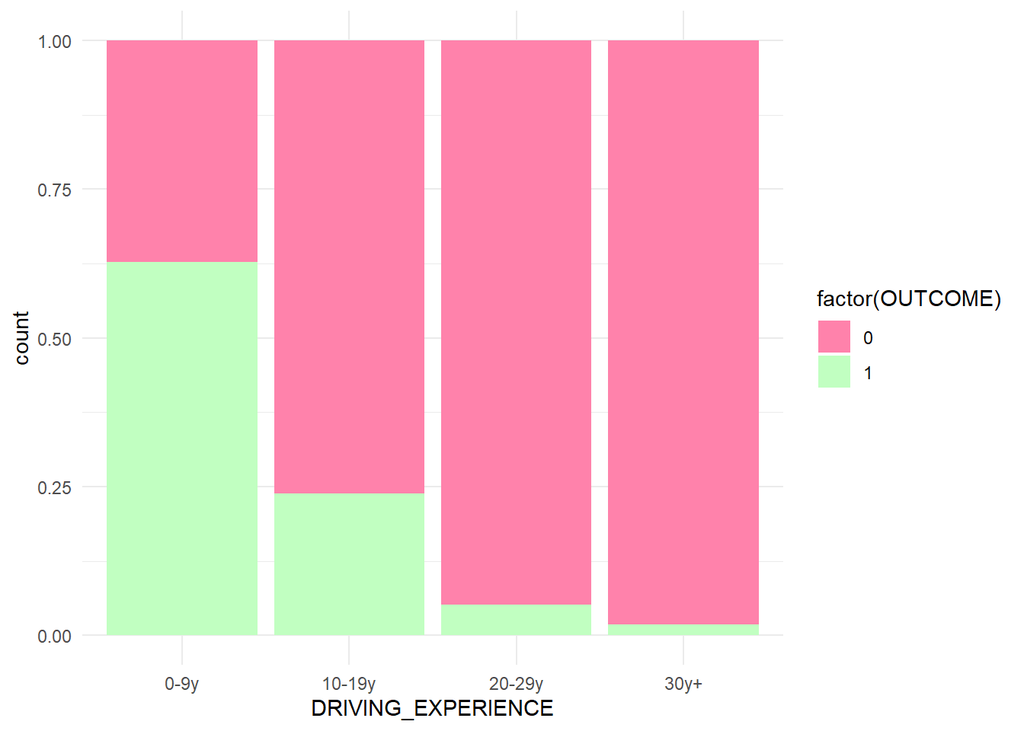

```r
ggplot(data = insurance) +
  geom_bar(aes(x = DRIVING_EXPERIENCE, fill = factor(OUTCOME)), position = "fill") +
  scale_fill_manual(values = c("palevioletred1", "darkseagreen1")) +
  theme_minimal()
```

The graphic presented above demonstrates a notable correlation between driving experience and the likelihood of a client filing an insurance claim. A correlation has been seen between less driving experience and a notable increase in the frequency of insurance claims.

## 4.7 Investigating *Education*

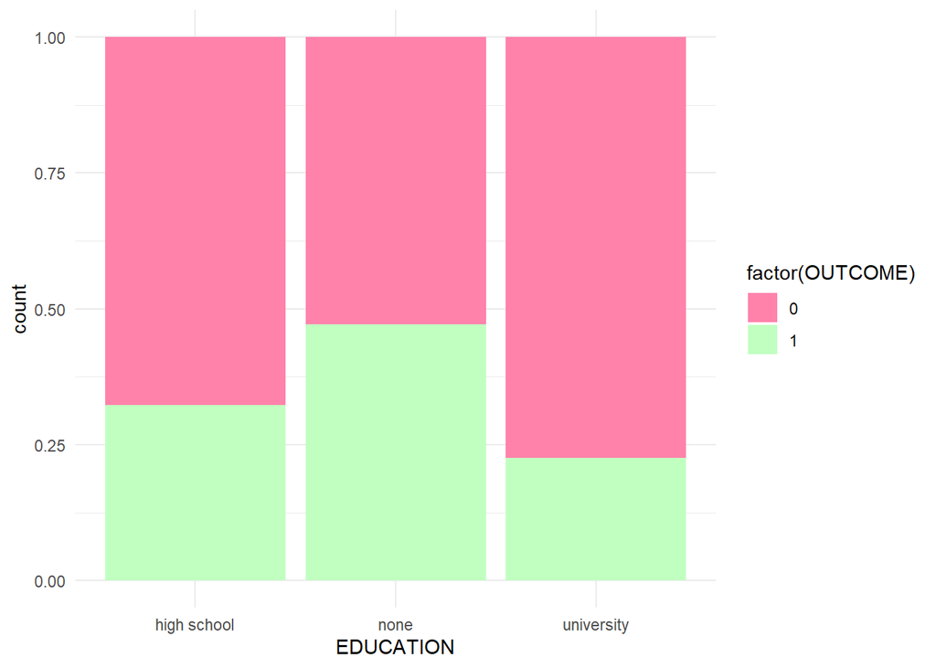

```r
ggplot(data = insurance) +
  geom_bar(aes(x = EDUCATION, fill = factor(OUTCOME)), position = "fill") +
  scale_fill_manual(values = c("palevioletred1", "darkseagreen1")) +
  theme_minimal()
```

The graphic presented above illustrates the potential relationship between education and the predictor variable of insurance claim. Individuals who have obtained a university degree exhibit a lower proportion of claims in comparison to those with a high school education, who in turn demonstrate a larger percentage of claims. Moreover, individuals with no formal education have the highest percentage of claims.

## 4.8 Investigating *Income*

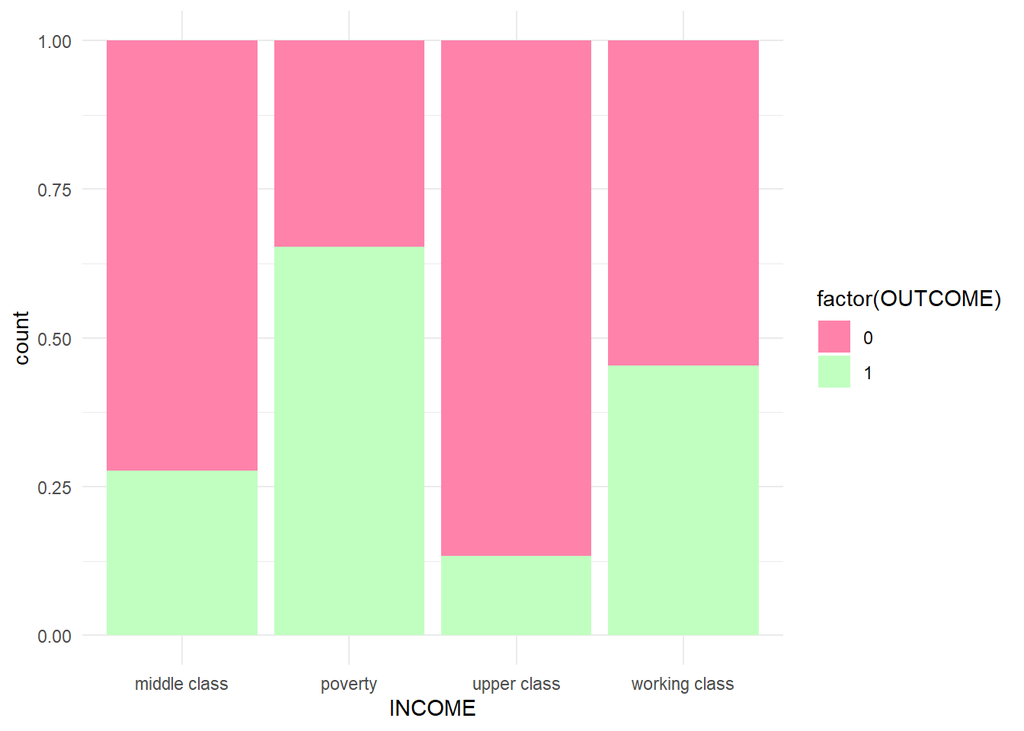

```r
ggplot(data = insurance) +
  geom_bar(aes(x = INCOME, fill = factor(OUTCOME)), position = "fill") +
  scale_fill_manual(values = c("palevioletred1", "darkseagreen1")) +
  theme_minimal()
```

## 4.9 Investigating *Credit Score*

To investigate the relationship between variable “CREDIT_SCORE”, since the variable “CREDIT_SCORE” is numerical, we report the bar plot with density as follows:

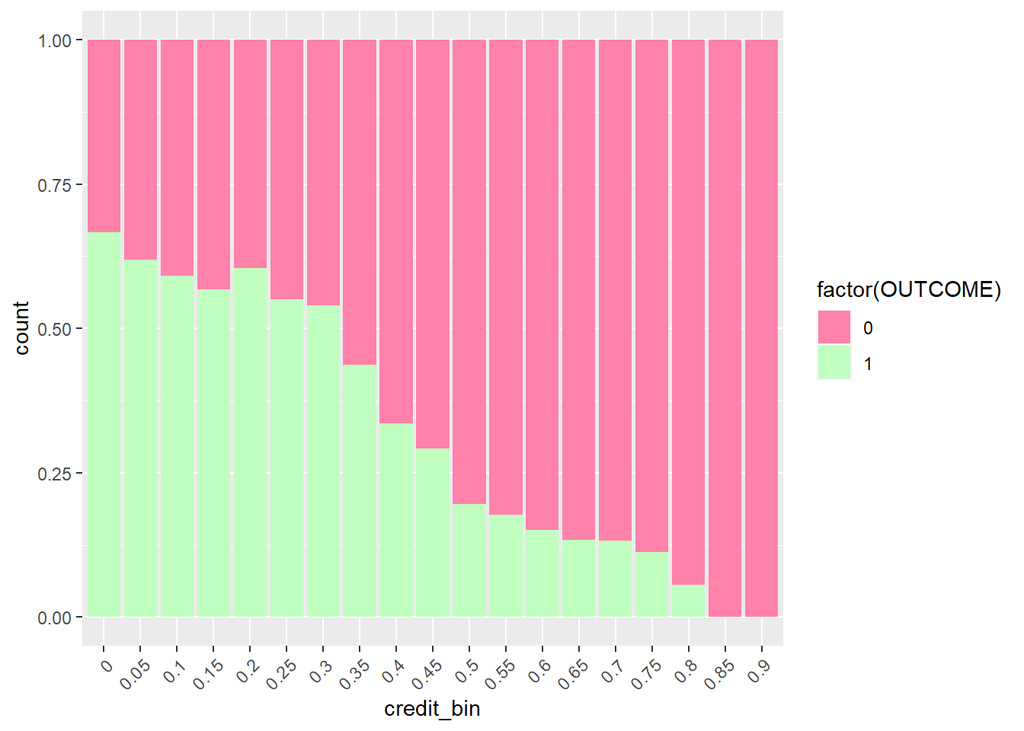

```r
insurance$CREDIT_SCORE <- as.numeric(insurance$CREDIT_SCORE)

breaks <- seq(0, 1, by = 0.05)

insurance$credit_bin <- cut(insurance$CREDIT_SCORE, breaks)

ggplot(data = insurance) +
  geom_bar(aes(x = credit_bin, fill = factor(OUTCOME)), position = "fill") +
  scale_fill_manual(values = c("palevioletred1", "darkseagreen1")) +
  scale_x_discrete(labels = as.character(breaks)) +
  theme(axis.text.x = element_text(angle = 45, hjust = 1))
```

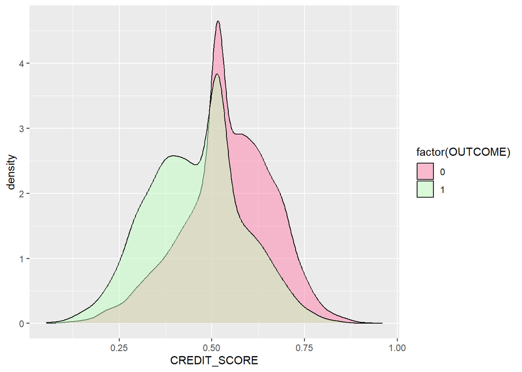

```r
ggplot(insurance, aes(x = CREDIT_SCORE, fill = factor(OUTCOME))) +
  geom_density(alpha = 0.5) +
  scale_fill_manual(values = c("0" = "palevioletred1", "1" = "darkseagreen1"))+
  xlab("CREDIT_SCORE")
```

The presented graphs demonstrate a positive correlation between lower credit scores and an increased proportion of insurance claims.

## 4.10 Investigating *Vehicle Ownership*

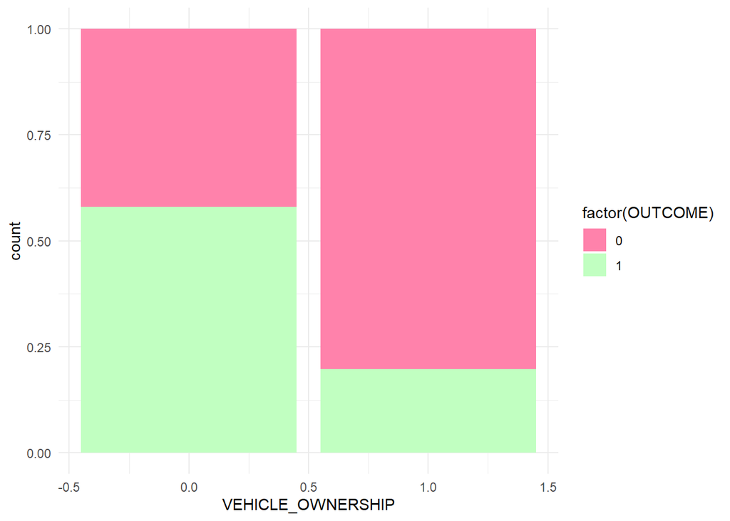

```r
ggplot(data = insurance) +
  geom_bar(aes(x = VEHICLE_OWNERSHIP, fill = factor(OUTCOME)), position = "fill") +
  scale_fill_manual(values = c("palevioletred1", "darkseagreen1")) +
  theme_minimal()
```

The data depicted in the plot indicates that those who do not possess a car exhibit a greater proportion of claiming insurance.

## 4.11 Investigating *Vehicle Year*

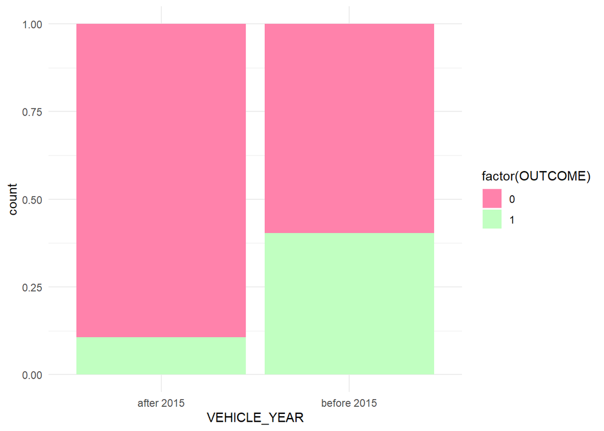

```r
ggplot(data = insurance) +
  geom_bar(aes(x = VEHICLE_YEAR, fill = factor(OUTCOME)), position = "fill") +
  scale_fill_manual(values = c("palevioletred1", "darkseagreen1")) +
  theme_minimal()
```

The data presented in the plot indicates that individuals who possess a car manufactured prior to 2015 have a greater proportion of insurance claims.

## 4.12 Investigating *Marriage Status*

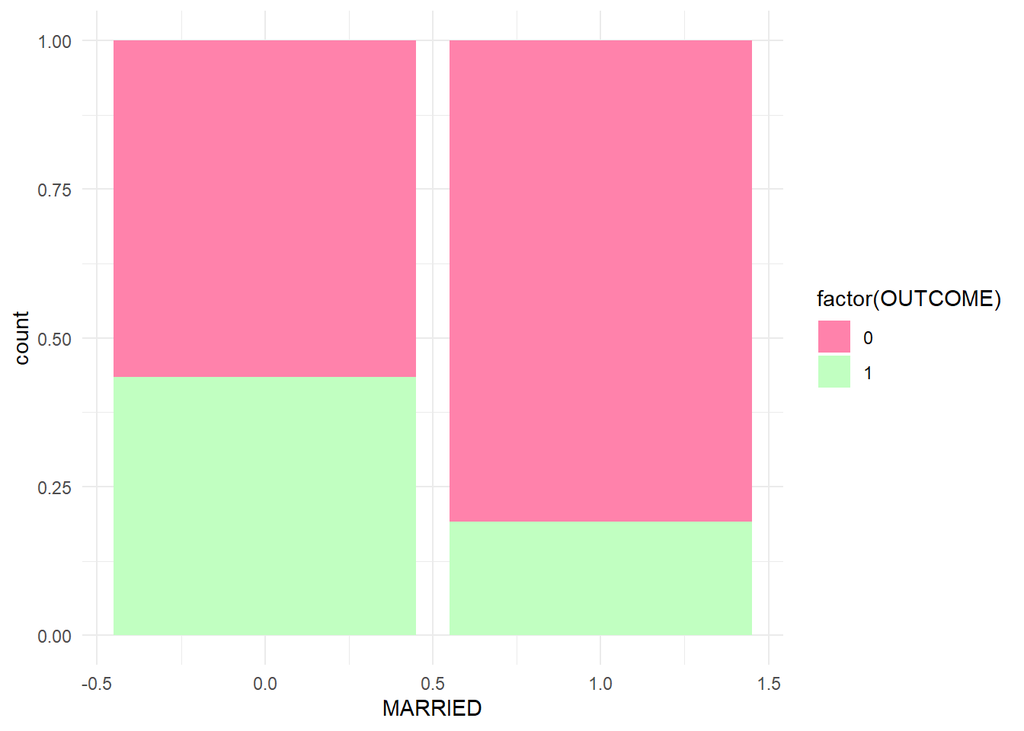

```r
ggplot(data = insurance) +
  geom_bar(aes(x = MARRIED, fill = factor(OUTCOME)), position = "fill") +
  scale_fill_manual(values = c("palevioletred1", "darkseagreen1")) +
  theme_minimal()
```

The data presented in the plot indicates that individuals who are not married exhibit a greater proportion of insurance claims.

## 4.13 Investigating *Parenthood*

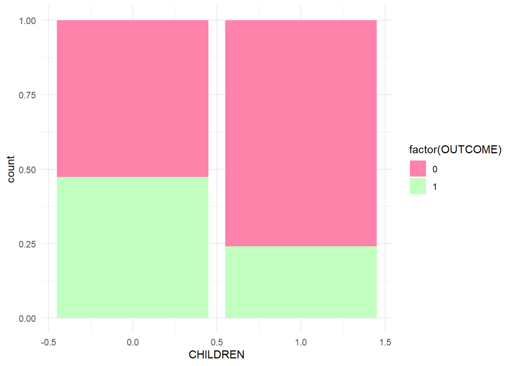

```r
ggplot(data = insurance) +
  geom_bar(aes(x = CHILDREN, fill = factor(OUTCOME)), position = "fill") +
  scale_fill_manual(values = c("palevioletred1", "darkseagreen1")) +
  theme_minimal()
```

The graphic presented above illustrates a somewhat higher frequency of insurance claims being filed by drivers with no children.

The above plot does not indicate a very clear graphical evidence of the predictive importance of *Children*. Thus, we apply the following hypothesis testing for dependency between variables *Children* and *Outcome*

```r
chisq.test( table( insurance $ OUTCOME, insurance $ CHILDREN ) )
```

```
    Pearson's Chi-squared test with Yates' continuity correction

  data:  table(insurance$OUTCOME, insurance$CHILDREN)
  X-squared = 541.04, df = 1, p-value < 2.2e-16
```

Since the *p*-value < 2.2e-16 is less than the significance level of $\alpha=0.05$, the null hypothesis is rejected. This implies that the proportion of insurance claims differs between the two groups, and that the variable `Children` is useful for predicting the proportion of insurance claims filed.

## 4.14 Investigating *Postal Code*

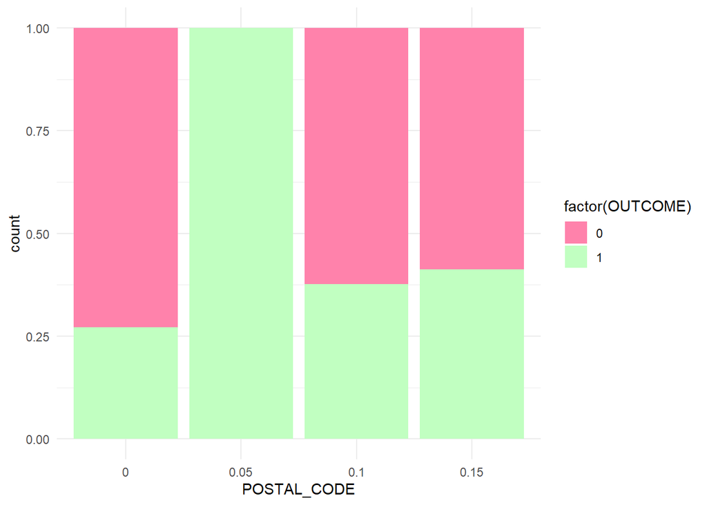

```r
insurance$POSTAL_CODE <- factor(insurance$POSTAL_CODE)

ggplot(data = insurance) +
  geom_bar(aes(x = POSTAL_CODE, fill = factor(OUTCOME)), position = "fill") +
  scale_fill_manual(values = c("palevioletred1", "darkseagreen1")) +
  scale_x_discrete(labels = as.character(breaks)) +
  theme_minimal()
```

The plot illustrates that three postal codes exhibit comparable proportions of insurance claims, while one postal code stands out with a 100% rate of insurance claims. Further investigation is necessary before drawing any definitive conclusions.

## 4.15 Investigating *Annual Mileage*

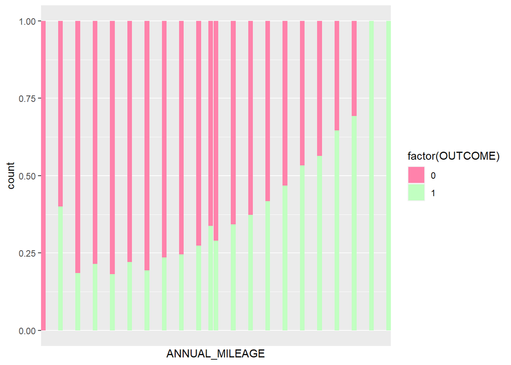

```r
ggplot(data = insurance) +
  geom_bar(aes(x = ANNUAL_MILEAGE, fill = factor(OUTCOME)), position = "fill") +
  scale_fill_manual(values = c("palevioletred1", "darkseagreen1"))+
  scale_x_discrete(labels = as.character(breaks)) +
  theme(axis.text.x = element_text(angle = 45, hjust = 1))
```

## 4.16 Investigating *Vehicle Type*

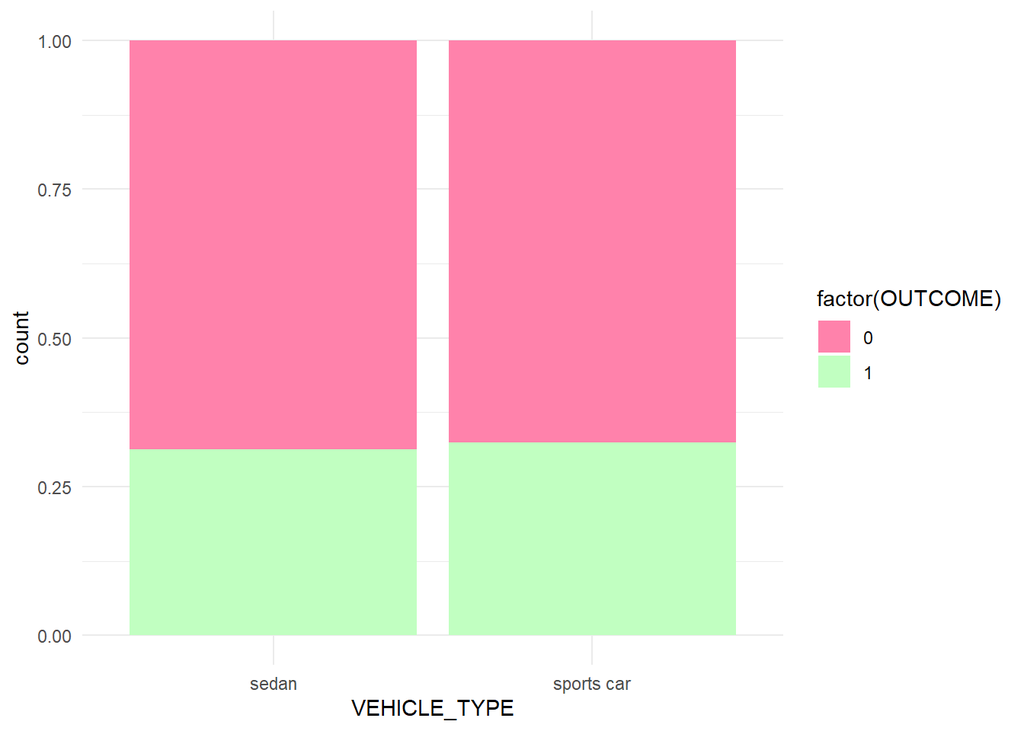

```r
ggplot(data = insurance) +
  geom_bar(aes(x = VEHICLE_TYPE, fill = factor(OUTCOME)), position = "fill") +
  scale_fill_manual(values = c("palevioletred1", "darkseagreen1")) +
  theme_minimal()
```

The graphic presented above indicates that there is no statistically significant variation in the proportion of insurance claims based on the kind of vehicle.

The above plot does not indicate a clear graphical evidence of the predictive importance of *Vehicle_type*. Thus, we apply the following hypothesis testing for dependency between variables *Vehicle_type* and *Outcome*

```r
chisq.test( table( insurance $ OUTCOME, insurance $ VEHICLE_TYPE ) )
```

```
    Pearson's Chi-squared test with Yates' continuity correction

  data:  table(insurance$OUTCOME, insurance$VEHICLE_TYPE)
  X-squared = 0.26156, df = 1, p-value = 0.609
```

Since the *p*-value = 0.609 is more than the significance level of $\alpha=0.05$, the null hypothesis is not rejected. This implies that the proportion of insurance claims does not differ between the two groups, and that the variable `Vehicle_type` is not useful for predicting the proportion of insurance claims filed.

## 4.17 Investigating *Speeding Violations*

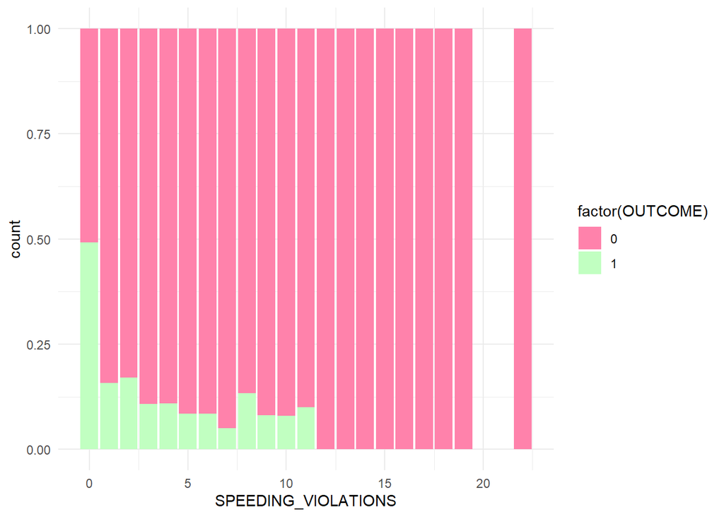

```r
ggplot(data = insurance) +
  geom_bar(aes(x = SPEEDING_VIOLATIONS, fill = factor(OUTCOME)), position = "fill") +
  scale_fill_manual(values = c("palevioletred1", "darkseagreen1")) +
  theme_minimal()
```

## 4.18 Investigating *DUIs*

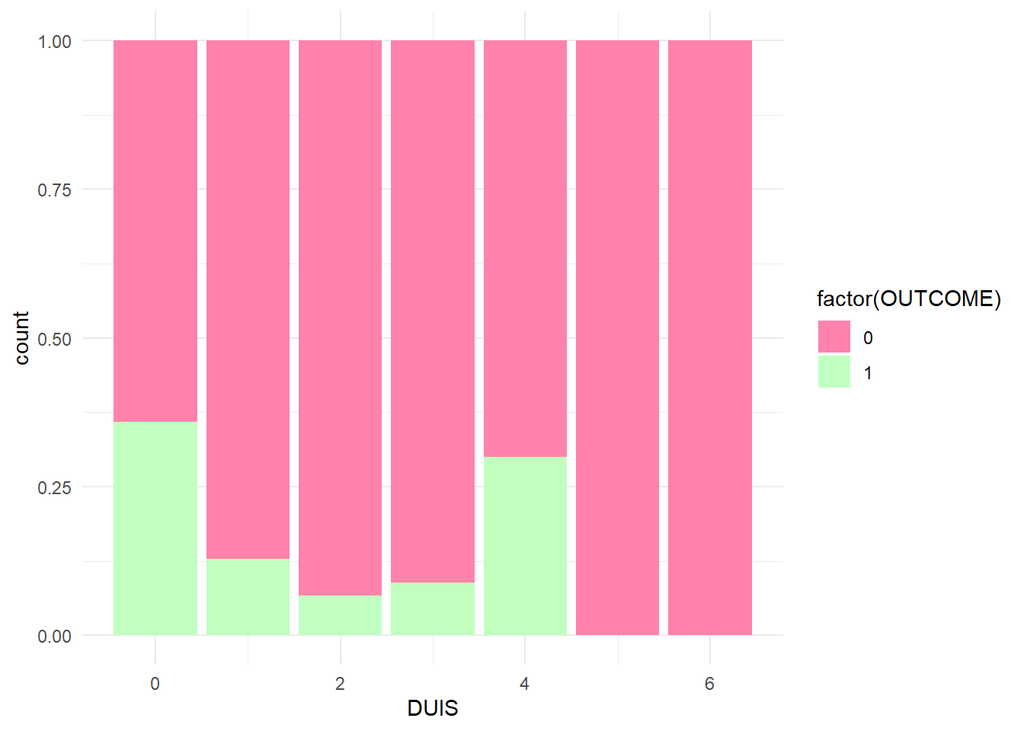

```r
ggplot(data = insurance) +
  geom_bar(aes(x = DUIS, fill = factor(OUTCOME)), position = "fill") +
  scale_fill_manual(values = c("palevioletred1", "darkseagreen1")) +
  theme_minimal()
```

It is evident that individuals with either no DUIs or four DUIs exhibit a proportionately higher rate of insurance claims, exceeding double the rate observed among individuals with other numbers of DUIs. The high proportion of insurance claims for drivers with absence of driving under the influence (DUI) incidents may be attributed to the prevalence of inexperienced drivers.

## 4.19 Investigating *Past Accidents*

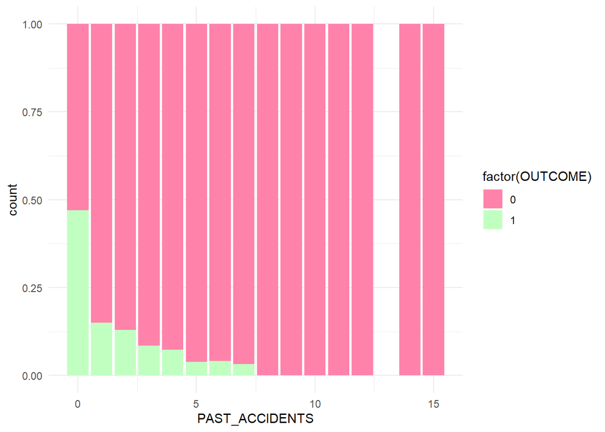

```r
ggplot(data = insurance) +
  geom_bar(aes(x = PAST_ACCIDENTS, fill = factor(OUTCOME)), position = "fill") +
  scale_fill_manual(values = c("palevioletred1", "darkseagreen1")) +
  theme_minimal()
```

Based on the depicted plot, it is evident that there exists an inverse relationship between the frequency of accidents and the corresponding rate of insurance claims. This observation may be attributed to the notion that increased experience tends to result in a decreased likelihood of accidents occurring.

## 4.20 Inference

The overarching conclusion of this initial analysis is that there is an inverse relationship between driving experience and the frequency of accidents, resulting in a lower proportion of insurance claims. This can be seen from the results from of following variables: `age`, `driving experience`, `married`, `children`, `speeding violations` and `past accidents`. Moreover, male drivers and lower income and education classes have higher proportion of accidents. As well as the fact if the vehicle is owned by the driver and if it’s older than 2015 play a role in determining the proportion of insurance claim.

# 5 Feature Importance

Selecting the most important predictor variables that explains the major part of variance of the response variable can be key to identify and build high performing models. We have gotten a gist of the data and how the predictor variables behave in regard to the target variable from the EDA. However, it is important to algorithmically justify feature extraction before moving on to training models.

```r
boruta_output <- Boruta(OUTCOME ~ ., data=na.omit(insurance), doTrace=0)

# Get significant variables
boruta_signif = getSelectedAttributes(boruta_output, withTentative = FALSE)
print(boruta_signif)
```

```
   [1] "AGE"                 "GENDER"              "DRIVING_EXPERIENCE"
   [4] "INCOME"              "CREDIT_SCORE"        "VEHICLE_OWNERSHIP"
   [7] "VEHICLE_YEAR"        "MARRIED"             "CHILDREN"
  [10] "POSTAL_CODE"         "ANNUAL_MILEAGE"      "SPEEDING_VIOLATIONS"
  [13] "DUIS"                "PAST_ACCIDENTS"      "credit_bin"
```

# 6 Data Preparation

## 6.1 Convert target variable to factor

```r
str(insurance)
```

```
  'data.frame': 10000 obs. of  20 variables:
   $ ID                 : int  569520 750365 199901 478866 731664 877557 930134 461006 68366 445911 ...
   $ AGE                : chr  "65+" "16-25" "16-25" "16-25" ...
   $ GENDER             : chr  "female" "male" "female" "male" ...
   $ RACE               : chr  "majority" "majority" "majority" "majority" ...
   $ DRIVING_EXPERIENCE : chr  "0-9y" "0-9y" "0-9y" "0-9y" ...
   $ EDUCATION          : chr  "high school" "none" "high school" "university" ...
   $ INCOME             : chr  "upper class" "poverty" "working class" "working class" ...
   $ CREDIT_SCORE       : num  0.629 0.358 0.493 0.206 0.388 ...
   $ VEHICLE_OWNERSHIP  : num  1 0 1 1 1 1 0 0 0 1 ...
   $ VEHICLE_YEAR       : chr  "after 2015" "before 2015" "before 2015" "before 2015" ...
   $ MARRIED            : num  0 0 0 0 0 0 1 0 1 0 ...
   $ CHILDREN           : num  1 0 0 1 0 1 1 1 0 1 ...
   $ POSTAL_CODE        : Factor w/ 4 levels "10238","21217",..: 1 1 1 3 3 1 1 1 1 3 ...
   $ ANNUAL_MILEAGE     : 'impute' num  12000 16000 11000 11000 12000 13000 13000 14000 13000 11000 ...
    ..- attr(*, "imputed")= int [1:957] 14 16 17 19 59 65 66 93 102 103 ...
   $ VEHICLE_TYPE       : chr  "sedan" "sedan" "sedan" "sedan" ...
   $ SPEEDING_VIOLATIONS: int  0 0 0 0 2 3 7 0 0 0 ...
   $ DUIS               : int  0 0 0 0 0 0 0 0 0 0 ...
   $ PAST_ACCIDENTS     : int  0 0 0 0 1 3 3 0 0 0 ...
   $ OUTCOME            : num  0 1 0 0 1 0 0 1 0 1 ...
   $ credit_bin         : Factor w/ 20 levels "(0,0.05]","(0.05,0.1]",..: 13 8 10 5 8 13 10 10 11 12 ...
```

```r
insurance $ OUTCOME = factor(ifelse(insurance $ OUTCOME == 0,"No","Yes"))
head(insurance $ OUTCOME)
```

```
  [1] No  Yes No  No  Yes No
  Levels: No Yes
```

## 6.2 Train-Test split

Let’s split the data into train and test data with a 80/20 split.

```r
set.seed( 42 )
data_sets = partition( data = insurance, prob = c( 0.8, 0.2 ) )
```

```r
train_set = data_sets $ part1
test_set  = data_sets $ part2

actual_test  = test_set $ OUTCOME
```

## 6.3 Validating the train-test split

```r
x1 = sum( train_set $ OUTCOME == "Yes" )
x2 = sum( test_set  $ OUTCOME == "Yes" )

n1 = nrow( train_set )
n2 = nrow( test_set  )
```

$$\bigg\{ \begin{matrix} H_0:
x_1/n_1 = x_2/n_2 \\ H_a: x_1/n_1 \neq x_2/n_2 \end{matrix}$$

```r
prop.test( x = c( x1, x2 ), n = c( n1, n2 ) )
```

```
    2-sample test for equality of proportions with continuity correction

  data:  c(x1, x2) out of c(n1, n2)
  X-squared = 2.4474e-29, df = 1, p-value = 1
  alternative hypothesis: two.sided
  95 percent confidence interval:
   -0.02276951  0.02273624
  sample estimates:
     prop 1    prop 2
  0.3132967 0.3133133
```

Since the p-value = 1 is greater than alpha = 0.05, at 95% confidence level we do not reject the null hypothesis. Therefore, the division of the target variables in the training and test sets is acceptable.

```r
formula = OUTCOME ~ AGE + GENDER + DRIVING_EXPERIENCE + EDUCATION + INCOME + CREDIT_SCORE + VEHICLE_OWNERSHIP + VEHICLE_YEAR + MARRIED + CHILDREN + POSTAL_CODE + ANNUAL_MILEAGE + SPEEDING_VIOLATIONS + DUIS + PAST_ACCIDENTS
```

# 7 Modelling: Classification

## 7.1 kNN Algorithm

### 7.1.1 Finding optimal k

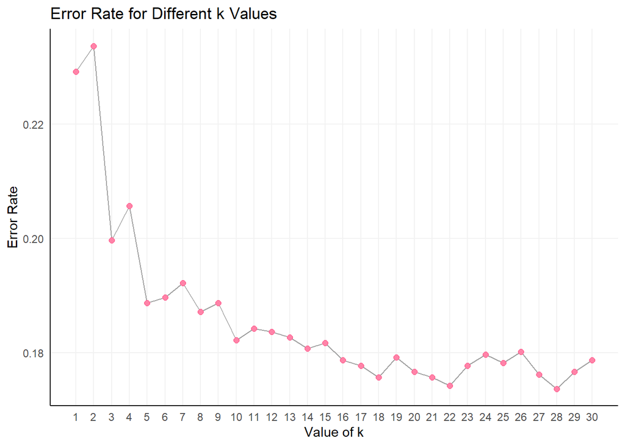

```r
kNN.plot( formula = formula, train = train_set, test = test_set, transform = "minmax", k.max = 30, set.seed = 42 )
```

Since k = 28 has the lowest error rate, we choose that as the optimal parameter for our kNN model.

### 7.1.2 Training the model

```r
predict_knn = kNN( formula = formula, train = train_set, test = test_set, transform = "minmax", k = 28 )
```

## 7.2 CART Algorithm

```r
tree_cart = rpart( formula = formula, data = train_set, method = "class" )

print( tree_cart )
```

```
  n= 8002

  node), split, n, loss, yval, (yprob)
        * denotes terminal node

   1) root 8002 2507 No (0.68670332 0.31329668)
     2) DRIVING_EXPERIENCE=10-19y,20-29y,30y+ 5199  728 No (0.85997307 0.14002693)
       4) VEHICLE_OWNERSHIP>=0.5 3951  322 No (0.91850165 0.08149835)
         8) POSTAL_CODE=10238,32765,92101 3894  265 No (0.93194658 0.06805342) *
         9) POSTAL_CODE=21217 57    0 Yes (0.00000000 1.00000000) *
       5) VEHICLE_OWNERSHIP< 0.5 1248  406 No (0.67467949 0.32532051)
        10) DRIVING_EXPERIENCE=20-29y,30y+ 454   34 No (0.92511013 0.07488987) *
        11) DRIVING_EXPERIENCE=10-19y 794  372 No (0.53148615 0.46851385)
          22) VEHICLE_YEAR=after 2015 160   29 No (0.81875000 0.18125000) *
          23) VEHICLE_YEAR=before 2015 634  291 Yes (0.45899054 0.54100946)
            46) GENDER=female 315  139 No (0.55873016 0.44126984)
              92) POSTAL_CODE=10238,92101 239   88 No (0.63179916 0.36820084) *
              93) POSTAL_CODE=21217,32765 76   25 Yes (0.32894737 0.67105263) *
            47) GENDER=male 319  115 Yes (0.36050157 0.63949843) *
     3) DRIVING_EXPERIENCE=0-9y 2803 1024 Yes (0.36532287 0.63467713)
       6) VEHICLE_YEAR=after 2015 630  173 No (0.72539683 0.27460317)
        12) VEHICLE_OWNERSHIP>=0.5 461   67 No (0.85466377 0.14533623) *
        13) VEHICLE_OWNERSHIP< 0.5 169   63 Yes (0.37278107 0.62721893) *
       7) VEHICLE_YEAR=before 2015 2173  567 Yes (0.26092959 0.73907041) *
```

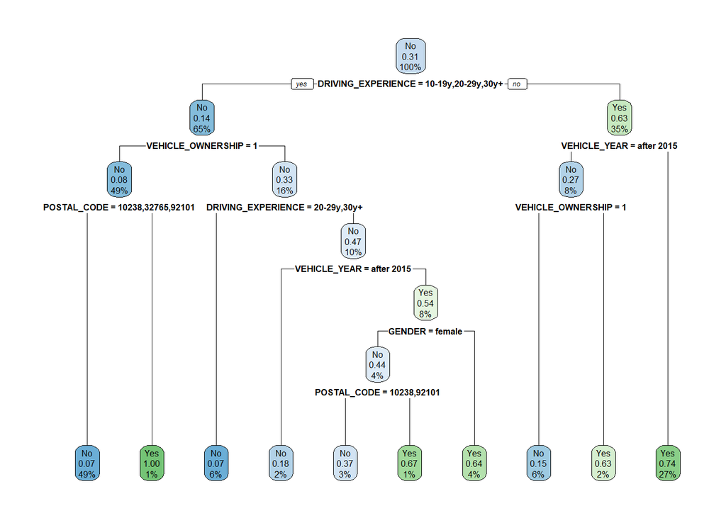

```r
rpart.plot( tree_cart )
```

## 7.3 Random Forest

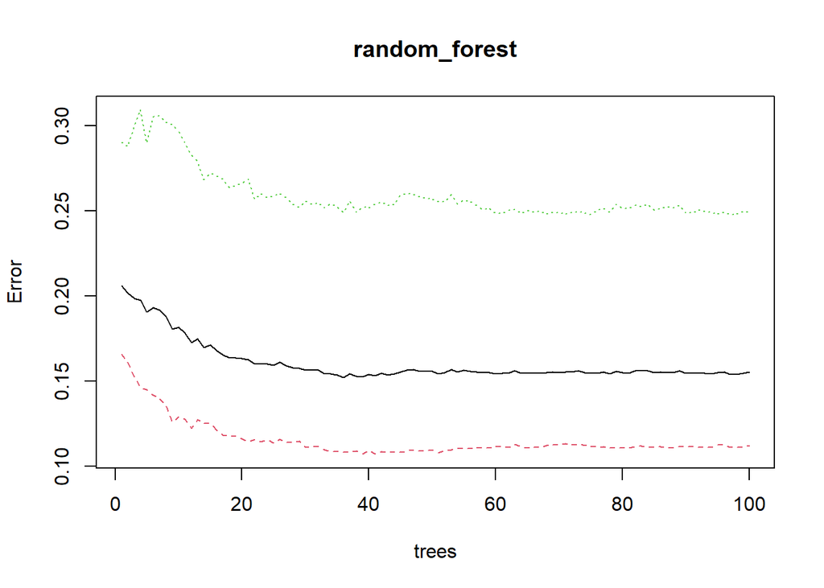

```r
random_forest = randomForest( formula = formula, data = train_set, ntree = 100 )
plot (random_forest)
```

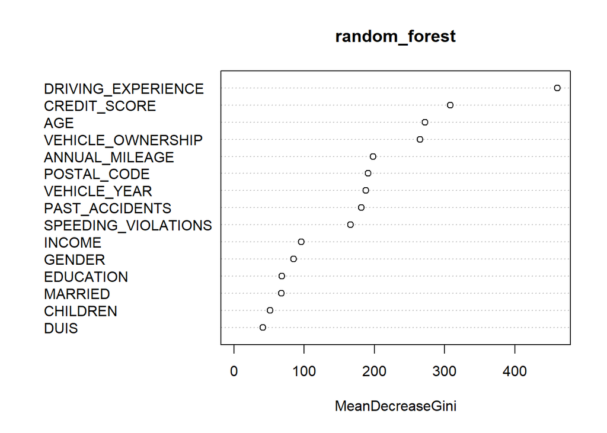

```r
varImpPlot( random_forest )
```

## 7.4 Logistic Regression

```r
logreg = glm( formula, data = train_set, family = binomial )
```

```r
summary( logreg )
```

```
  Call:
  glm(formula = formula, family = binomial, data = train_set)

  Deviance Residuals:
      Min       1Q   Median       3Q      Max
  -2.9539  -0.4504  -0.1354   0.3698   3.3144

  Coefficients:
                             Estimate Std. Error z value Pr(>|z|)
  (Intercept)              -2.213e+00  3.545e-01  -6.243 4.29e-10 ***
  AGE26-39                 -9.291e-02  1.189e-01  -0.782    0.434
  AGE40-64                 -4.814e-02  1.403e-01  -0.343    0.732
  AGE65+                    4.794e-02  1.768e-01   0.271    0.786
  GENDERmale                1.108e+00  7.738e-02  14.314  < 2e-16 ***
  DRIVING_EXPERIENCE10-19y -2.045e+00  1.180e-01 -17.327  < 2e-16 ***
  DRIVING_EXPERIENCE20-29y -4.189e+00  2.205e-01 -18.997  < 2e-16 ***
  DRIVING_EXPERIENCE30y+   -5.077e+00  4.340e-01 -11.696  < 2e-16 ***
  EDUCATIONnone             4.595e-03  9.739e-02   0.047    0.962
  EDUCATIONuniversity      -4.156e-02  9.008e-02  -0.461    0.645
  INCOMEpoverty             1.624e-01  1.364e-01   1.191    0.234
  INCOMEupper class         1.589e-02  1.199e-01   0.133    0.895
  INCOMEworking class       1.451e-01  1.115e-01   1.301    0.193
  CREDIT_SCORE              1.380e-01  3.843e-01   0.359    0.720
  VEHICLE_OWNERSHIP        -1.854e+00  8.178e-02 -22.671  < 2e-16 ***
  VEHICLE_YEARbefore 2015   2.046e+00  1.014e-01  20.169  < 2e-16 ***
  MARRIED                  -3.690e-01  8.398e-02  -4.394 1.11e-05 ***
  CHILDREN                 -7.151e-02  8.311e-02  -0.860    0.390
  POSTAL_CODE21217          2.106e+01  1.696e+02   0.124    0.901
  POSTAL_CODE32765          1.278e+00  9.634e-02  13.262  < 2e-16 ***
  POSTAL_CODE92101          1.503e+00  1.662e-01   9.045  < 2e-16 ***
  ANNUAL_MILEAGE            1.326e-04  1.721e-05   7.704 1.32e-14 ***
  SPEEDING_VIOLATIONS       2.945e-02  3.157e-02   0.933    0.351
  DUIS                     -1.036e-02  9.224e-02  -0.112    0.911
  PAST_ACCIDENTS           -6.398e-02  4.302e-02  -1.487    0.137
  ---
  Signif. codes:  0 '***' 0.001 '**' 0.01 '*' 0.05 '.' 0.1 ' ' 1

  (Dispersion parameter for binomial family taken to be 1)

      Null deviance: 9949.9  on 8001  degrees of freedom
  Residual deviance: 5086.4  on 7977  degrees of freedom
  AIC: 5136.4

  Number of Fisher Scoring iterations: 15
```

As we can see from the above summary of logistic regression, we should remove `AGE`, `EDUCATION`, `INCOME`, `CREDIT_SCORE`, `CHILDREN`, `SPEEDING_VIOLATIONS`, `DUIS` and `PAST_ACCIDENTS` since they have a p-value higher than alpha = 0.05, therefore they are not informative enough for our target variable.

```r
formula_logreg = OUTCOME ~ GENDER + DRIVING_EXPERIENCE + VEHICLE_OWNERSHIP + VEHICLE_YEAR + MARRIED + POSTAL_CODE + ANNUAL_MILEAGE
```

```r
logreg_2 = glm( formula_logreg, data = train_set, family = binomial )
```

```r
summary(logreg_2)
```

```
  Call:
  glm(formula = formula_logreg, family = binomial, data = train_set)

  Deviance Residuals:
      Min       1Q   Median       3Q      Max
  -2.9655  -0.4535  -0.1376   0.3797   3.3481

  Coefficients:
                             Estimate Std. Error z value Pr(>|z|)
  (Intercept)              -2.233e+00  2.416e-01  -9.244  < 2e-16 ***
  GENDERmale                1.087e+00  7.336e-02  14.817  < 2e-16 ***
  DRIVING_EXPERIENCE10-19y -2.147e+00  7.859e-02 -27.322  < 2e-16 ***
  DRIVING_EXPERIENCE20-29y -4.293e+00  1.583e-01 -27.130  < 2e-16 ***
  DRIVING_EXPERIENCE30y+   -5.096e+00  3.520e-01 -14.478  < 2e-16 ***
  VEHICLE_OWNERSHIP        -1.890e+00  7.687e-02 -24.589  < 2e-16 ***
  VEHICLE_YEARbefore 2015   2.087e+00  9.785e-02  21.327  < 2e-16 ***
  MARRIED                  -3.986e-01  8.064e-02  -4.943 7.68e-07 ***
  POSTAL_CODE21217          2.112e+01  1.693e+02   0.125    0.901
  POSTAL_CODE32765          1.332e+00  9.053e-02  14.716  < 2e-16 ***
  POSTAL_CODE92101          1.525e+00  1.652e-01   9.230  < 2e-16 ***
  ANNUAL_MILEAGE            1.408e-04  1.572e-05   8.957  < 2e-16 ***
  ---
  Signif. codes:  0 '***' 0.001 '**' 0.01 '*' 0.05 '.' 0.1 ' ' 1

  (Dispersion parameter for binomial family taken to be 1)

      Null deviance: 9949.9  on 8001  degrees of freedom
  Residual deviance: 5095.3  on 7990  degrees of freedom
  AIC: 5119.3

  Number of Fisher Scoring iterations: 15
```

As we can see, the updated model has a lower AIC which indicates a better fit.

# 8 Model Evaluation

## 8.1 Evaluating CART

```r
tree_cart = rpart( formula = formula, data = train_set, method = "class" )
predict_cart = predict( tree_cart, test_set, type = "class" )

conf.mat( predict_cart, actual_test )
```

```
         Actual
  Predict   No  Yes
      No  1161  124
      Yes  211  502
```

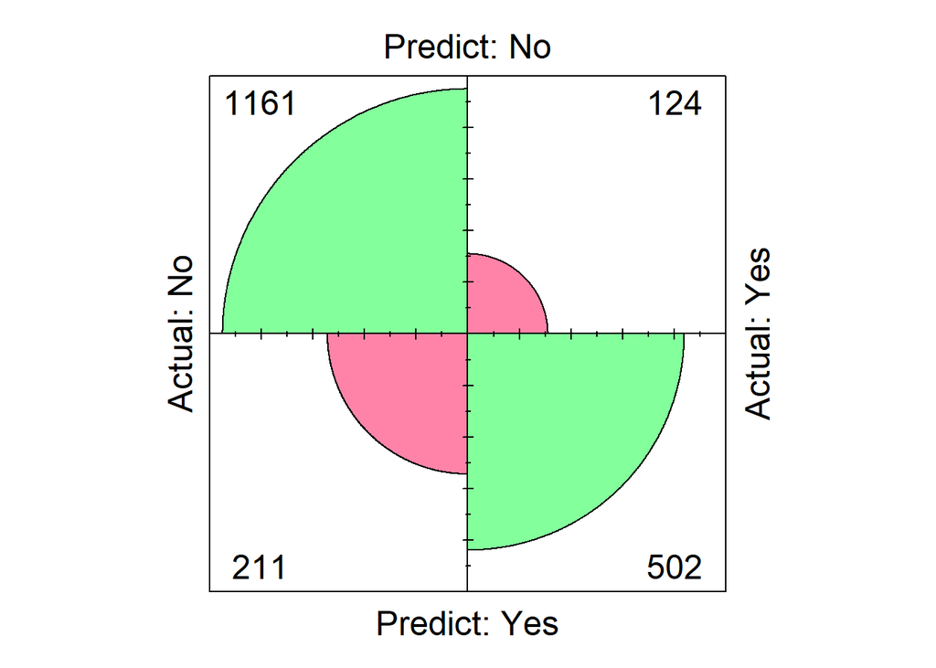

```r
conf.mat.plot( predict_cart, actual_test )
```

```r
( mse_cart = mse( predict_cart, actual_test ) )
```

```
  [1] 0.1676677
```

## 8.2 Evaluating Random Forest

```r
random_forest = randomForest( formula = formula, data = train_set, ntree = 100 )
predict_random_forest = predict( random_forest, test_set )

conf.mat( predict_random_forest, actual_test )
```

```
         Actual
  Predict   No  Yes
      No  1216  164
      Yes  156  462
```

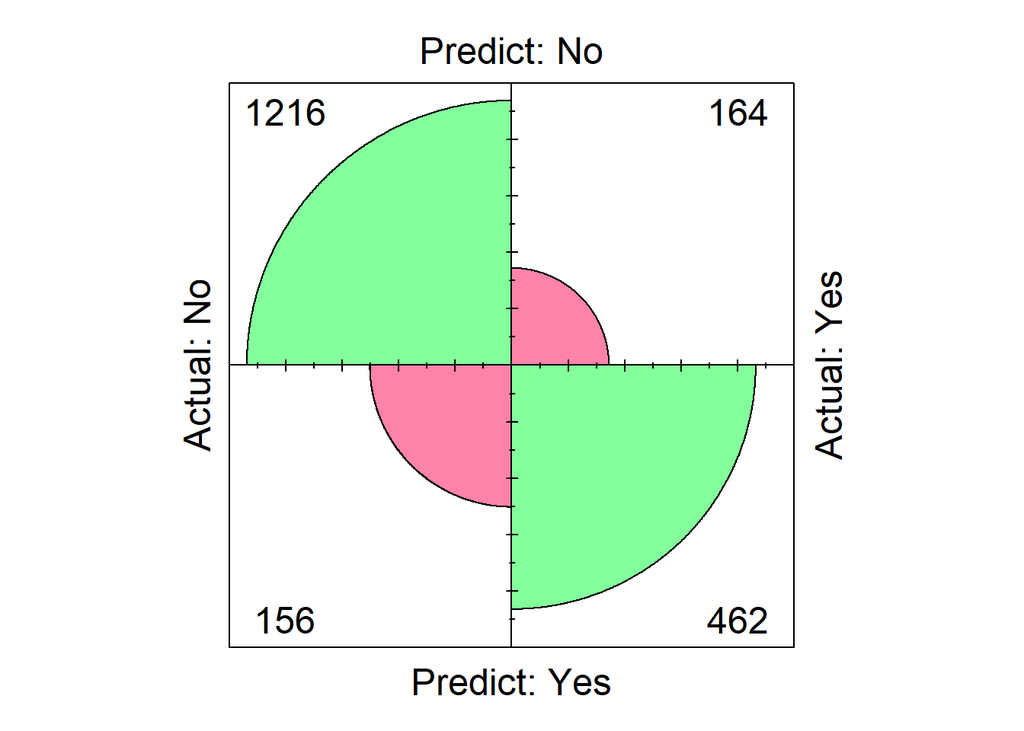

```r
conf.mat.plot( predict_random_forest, actual_test )
```

```r
( mse_random_forest = mse( predict_random_forest, actual_test ) )
```

```
  [1] 0.1601602
```

## 8.3 Evaluating kNN

```r
conf.mat( predict_knn, actual_test )
```

```
         Actual
  Predict   No  Yes
      No  1234  216
      Yes  138  410
```

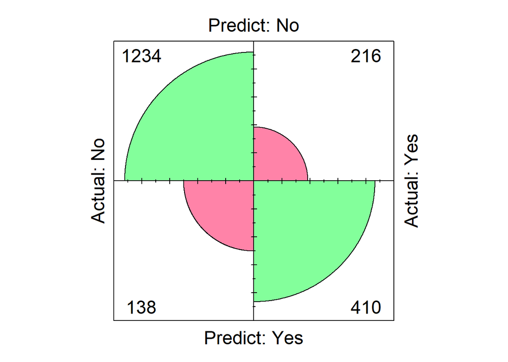

```r
conf.mat.plot( predict_knn, actual_test )
```

```r
( mse_knn = mse( predict_knn, actual_test ) )
```

```
  [1] 0.1771772
```

## 8.4 Evaluating Logistic Regression

```r
predict_logreg = predict( logreg_2, test_set, type = "response" )

( mse_logreg = mse( predict_logreg, actual_test ) )
```

```
  [1] 1.090675
```

## 8.5 ROC and AUC comparision

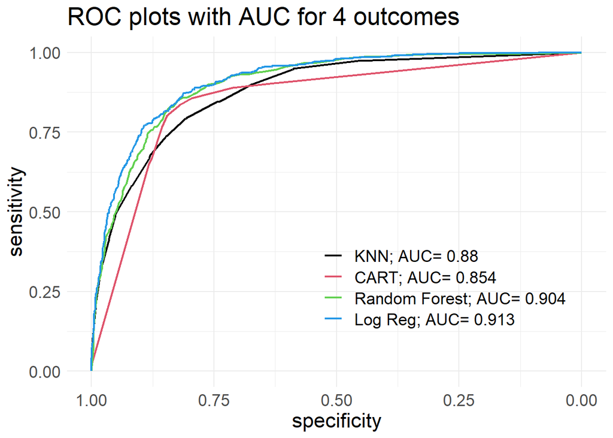

```r
prob_cart = predict( tree_cart, test_set, type = "prob" )[ , 1 ]

prob_random_forest = predict( random_forest, test_set, type = "prob" )[ , 1 ]

prob_knn = kNN( formula, train = train_set, test = test_set, transform = "minmax", k = 13, type = "prob" )[ , 1 ]

prob_logreg  = predict( logreg_2,  test_set, type = "response" )

roc_knn = roc( actual_test, prob_knn )
roc_cart = roc( actual_test, prob_cart )
roc_random_forest = roc( actual_test, prob_random_forest )
roc_logreg = roc( actual_test, prob_logreg )

ggroc( list( roc_knn, roc_cart, roc_random_forest, roc_logreg ), size = 0.8 ) +
    theme_minimal() + ggtitle( "ROC plots with AUC for 4 outcomes") +
  scale_color_manual( values = 1:4,
    labels = c( paste( "KNN; AUC=", round( auc( roc_knn ), 3 ) ),
                paste( "CART; AUC=", round( auc( roc_cart ), 3 ) ),
                paste( "Random Forest; AUC=", round( auc( roc_random_forest ), 3 ) ),
                paste( "Log Reg; AUC=", round( auc( roc_logreg ), 3 ) )
                ) ) +
  theme( legend.title = element_blank() ) +
  theme( legend.position = c( .7, .3 ), text = element_text( size = 17 ) )
```

# 9 Conclusion

In conclusion, the successful completion of this project marks a significant milestone in leveraging machine learning techniques to enhance the car insurance industry. Through the application of various classification models and feature engineering, we have been able to predict with a high degree of accuracy whether a customer is likely to file a car insurance claim. This achievement holds immense potential for insurance companies seeking to optimize their operations, allocate resources more efficiently, and ultimately provide better services to their clients.

Furthermore, this project provided valuable insights into the features that contribute most significantly to the prediction of insurance claims. This not only aids in understanding the underlying factors that drive customer behavior but also offers actionable intelligence for insurance companies to proactively engage with their clients and implement risk mitigation strategies.

All in all, this project has demonstrated the immense value that machine learning brings to the realm of car insurance prediction. By harnessing the power of data and advanced analytical techniques, we have laid the foundation for more informed decision-making, improved customer service, and ultimately, a more sustainable and competitive insurance industry.